# HelmNet_Full_Code

## **Problem Statement**

### **Business Context**

Workplace safety in hazardous environments like construction sites and industrial plants is crucial to prevent accidents and injuries. One of the most important safety measures is ensuring workers wear safety helmets, which protect against head injuries from falling objects and machinery. Non-compliance with helmet regulations increases the risk of serious injuries or fatalities, making effective monitoring essential, especially in large-scale operations where manual oversight is prone to errors and inefficiency.

To overcome these challenges, SafeGuard Corp plans to develop an automated image analysis system capable of detecting whether workers are wearing safety helmets. This system will improve safety enforcement, ensuring compliance and reducing the risk of head injuries. By automating helmet monitoring, SafeGuard aims to enhance efficiency, scalability, and accuracy, ultimately fostering a safer work environment while minimizing human error in safety oversight.

### **Objective**

As a data scientist at SafeGuard Corp, you are tasked with developing an image classification model that classifies images into one of two categories:

- **With Helmet:** Workers wearing safety helmets.
- **Without Helmet:** Workers not wearing safety helmets.

### **Data Description**

The dataset consists of **631 images**, equally divided into two categories:

- **With Helmet:** 311 images showing workers wearing helmets.
- **Without Helmet:** 320 images showing workers not wearing helmets.

**Dataset Characteristics:**

- **Variations in Conditions:** Images include diverse environments such as construction sites, factories, and industrial settings, with variations in lighting, angles, and worker postures to simulate real-world conditions.
- **Worker Activities:** Workers are depicted in different actions such as standing, using tools, or moving, ensuring robust model learning for various scenarios.

## **Installing and Importing the Necessary Libraries**

```python
# Install tensorflow and numpy
!pip install tensorflow[and-cuda] numpy==1.25.2 -q
```

```python
# Import tensorflow and check the version
import tensorflow as tf
print("Num GPUs Available:", len(tf.config.list_physical_devices('GPU')))
print(tf.__version__)
```

```
Num GPUs Available: 0
2.11.1
```

**Note:**

- After running the above cell, kindly restart the notebook kernel (for Jupyter Notebook) or runtime (for Google Colab) and run all cells sequentially from the next cell.
- On executing the above line of code, you might see a warning regarding package dependencies. This error message can be ignored as the above code ensures that all necessary libraries and their dependencies are maintained to successfully execute the code in this notebook.

```python
import os
import random
import numpy as np                 # Importing numpy for Matrix Operations
import pandas as pd                # Importing pandas to read CSV files
import seaborn as sns               # Importing seaborn for visualizations/plots
import matplotlib.pyplot as plt     # Importting matplotlib for Plotting and visualizing images
import math                         # Importing math module to perform mathematical operations
import cv2


# Tensorflow modules
import keras
import tensorflow as tf
from tensorflow.keras.preprocessing.image import ImageDataGenerator   # Importing the ImageDataGenerator for data augmentation
from tensorflow.keras.models import Sequential               # Importing the sequential module to define a sequential model
from tensorflow.keras.layers import Dense,Dropout,Flatten,Conv2D,MaxPooling2D # Defining all the layers to build our CNN Model
from tensorflow.keras.optimizers import Adam,SGD              # Importing the optimizers which can be used in our model
from sklearn import preprocessing                             # Importing the preprocessing module to preprocess the data
from sklearn.model_selection import train_test_split          # Importing train_test_split function to split the data into train and test
from sklearn.metrics import confusion_matrix
from tensorflow.keras.models import Model
from keras.applications.vgg16 import VGG16                                               # Importing confusion_matrix to plot the confusion matrix

# Display images using OpenCV
from PIL import Image

#Imports functions for evaluating the performance of machine learning models
from sklearn.metrics import confusion_matrix, f1_score,accuracy_score, recall_score, precision_score, classification_report
from sklearn.metrics import mean_squared_error as mse

# Ignore warnings
import warnings
warnings.filterwarnings('ignore')
```

```python
# Set the seed using keras.utils.set_random_seed. This will set:
# 1) `numpy` seed
# 2) backend random seed
# 3) `python` random seed
tf.keras.utils.set_random_seed(47)

# If using TensorFlow, this will make GPU ops as deterministic as possible,
# but it will affect the overall performance, so be mindful of that.
tf.config.experimental.enable_op_determinism()
```

## **Data Overview**

### **Loading the data**

```python
# Load the image file of the dataset
images = np.load('images_proj.npy')

# Load the labels file of the dataset
labels = pd.read_csv('Labels_proj.csv')
```

**Let's print the shape of the images and labels**

```python
print(images.shape)
print(labels.shape)
```

```
(631, 200, 200, 3)
(631, 1)
```

- We have 631 image samples of size 200 x 200 with BGR channels
- Labels are avaiable for each image indicating 0 (no helmet) and 1 (with hemlet)

**Let's plot a random image from the dataset**

[figure not shown]

```python
plt.imshow(images[13]);
```

## **Exploratory Data Analysis**

**Images need to be converted from BGR to RGB format**

```python
# Converting the images from BGR to RGB using cvtColor function of OpenCV
for i in range(len(images)):
  images[i] = cv2.cvtColor(images[i], cv2.COLOR_BGR2RGB)
```

**Utility function to plot the images**

```python
def plot_images(images,labels):
  num_classes=2                # Number of Classes
  categories=np.unique(labels)
  keys=dict(labels['Label'])     # Obtaing the unique classes from y_train
  rows = 3                       # Defining number of rows=3
  cols = 4                       # Defining number of columns=4
  fig = plt.figure(figsize=(10, 8))   # Defining the figure size to 10x8
  for i in range(cols):
      for j in range(rows):
          random_index = np.random.randint(0, len(labels))   # Generating random indices from the data and plotting the images
          ax = fig.add_subplot(rows, cols, i * rows + j + 1) # Adding subplots with 3 rows and 4 columns
          ax.imshow(images[random_index, :])  # Plotting the image
          ax.set_title(keys[random_index])
  plt.show()
```

**Plot random images from each of the classes and print their corresponding labels.**

[figure not shown]

```python
plot_images(images,labels)
```

- Images are in varying settings, some are potraits while some are in actual industrial settings
- Helmet colors also differ across images but shapes seem more or less consistent

**Checking for class imbalance**

```python
labels['Label'].value_counts()
```

```
Label
0    320
1    311
Name: count, dtype: int64
```

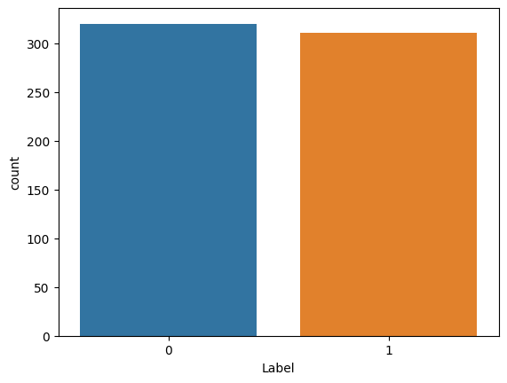

```python
sns.countplot(data=labels, x='Label', palette=['#1f77b4', '#ff7f0e']);
```

- Dataset is more or less balanced, so we don't need to employ class balancing techniques

# **Data Preprocessing**

### **Resize the image**

**Converting images to a more manageable 64x64 shape for computational effeciency**

```python
images_resized = []
height = 64
width = 64
dimensions = (width, height)
for i in range(len(images)):
  images_resized.append(cv2.resize(images[i], dimensions, interpolation=cv2.INTER_LINEAR))
```

### **Converting images to grayscale**

```python
# Converting color images to grayscale
grayscale_images = []
for i in range(len(images_resized)):
    grayscale_images.append(cv2.cvtColor(images_resized[i], cv2.COLOR_BGR2GRAY))
```

**Plotting few images side by side after and before preprocessing**

[figure not shown]

```python
indices = [3, 13, 62, 23]
fig, axes = plt.subplots(len(indices), 2, figsize=(6, 3*len(indices)))
for i, idx in enumerate(indices):
    axes[i, 0].imshow(images[idx])
    axes[i, 0].set_title(f"Index {idx} - Color")
    axes[i, 0].axis("off")

    axes[i, 1].imshow(grayscale_images[idx], cmap="gray")
    axes[i, 1].set_title(f"Index {idx} - Grayscale")
    axes[i, 1].axis("off")

plt.tight_layout()
plt.show()
```

- Images do lose a lot of information when turned to grayscale after resizing

### **Splitting the dataset**

**Splitting grayscale images into train, validation and test**

```python
X_train, X_temp, y_train, y_temp = train_test_split(np.array(grayscale_images),labels , test_size=0.2, random_state=42,stratify=labels)
X_val, X_test, y_val, y_test = train_test_split(X_temp,y_temp , test_size=0.5, random_state=42,stratify=y_temp)
```

**Splitting colored images into train, validation and test**

```python
X_train_c, X_temp_c, y_train_c, y_temp_c = train_test_split(np.array(images_resized), labels , test_size=0.2, random_state=42, stratify=labels)
X_val_c, X_test_c, y_val_c, y_test_c = train_test_split(X_temp_c, y_temp_c , test_size=0.5, random_state=42, stratify=y_temp_c)
```

### **Data Normalization**

```python
# Normalizing the image pixels
X_train_normalized = X_train.astype('float32')/255.0
X_val_normalized = X_val.astype('float32')/255.0
X_test_normalized = X_test.astype('float32')/255.0
```

```python
X_train_normalized_ = X_train_normalized[..., np.newaxis]
X_val_normalized_ = X_val_normalized[..., np.newaxis]
X_test_normalized_ = X_test_normalized[..., np.newaxis]
```

```python
# Normalizing the colored image pixels
X_train_c_normalized = X_train_c.astype('float32')/255.0
X_val_c_normalized = X_val_c.astype('float32')/255.0
X_test_c_normalized = X_test_c.astype('float32')/255.0
```

# **Model Building**

### **Utility Functions**

```python
# defining a function to compute different metrics to check performance of a classification model built using statsmodels
def model_performance_classification(model, predictors, target):
    """
    Function to compute different metrics to check classification model performance

    model: classifier
    predictors: independent variables
    target: dependent variable
    """

    # checking which probabilities are greater than threshold
    pred = model.predict(predictors).reshape(-1)>0.5

    target = target.to_numpy().reshape(-1)


    acc = accuracy_score(target, pred)  # to compute Accuracy
    recall = recall_score(target, pred, average='weighted')  # to compute Recall
    precision = precision_score(target, pred, average='weighted')  # to compute Precision
    f1 = f1_score(target, pred, average='weighted')  # to compute F1-score

    # creating a dataframe of metrics
    df_perf = pd.DataFrame({"Accuracy": acc, "Recall": recall, "Precision": precision, "F1 Score": f1,},index=[0],)

    return df_perf
```

```python
def plot_confusion_matrix(model,predictors,target,ml=False):
    """
    Function to plot the confusion matrix

    model: classifier
    predictors: independent variables
    target: dependent variable
    ml: To specify if the model used is an sklearn ML model or not (True means ML model)
    """

    # checking which probabilities are greater than threshold
    pred = model.predict(predictors).reshape(-1)>0.5

    target = target.to_numpy().reshape(-1)

    # Plotting the Confusion Matrix using confusion matrix() function which is also predefined tensorflow module
    confusion_matrix = tf.math.confusion_matrix(target,pred)
    f, ax = plt.subplots(figsize=(10, 8))
    sns.heatmap(
        confusion_matrix,
        annot=True,
        linewidths=.4,
        fmt="d",
        square=True,
        ax=ax
    )
    plt.show()
```

## **Model 1 : Simple Convolutional Neural Network (CNN)**

```python
# Define the CNN model

model_cnn = Sequential([
    # 1st Convolutional Layer
    Conv2D(filters=4, kernel_size=(3,3), activation='relu', input_shape=(64, 64, 1)),
    MaxPooling2D(pool_size=(2,2)),

    # 2nd Convolutional Layer
    Conv2D(filters=8, kernel_size=(3,3), activation='relu'),
    MaxPooling2D(pool_size=(2,2)),

    # Flatten before Fully Connected Layers
    Flatten(),

    # Fully Connected Layers
    Dense(64, activation='relu'),
    Dropout(0.5),
    Dense(32, activation='relu'),

    # Output Layer (for binary classification)
    Dense(1, activation='sigmoid')
])

# Compile the model
model_cnn.compile(optimizer='adam', loss='binary_crossentropy', metrics=['accuracy'])

# Summary
model_cnn.summary()
```

[output not shown]

```python
# Image generator
train_datagen = ImageDataGenerator()
```

```python
epochs = 20 # Epochs
batch_size = 64 # Batch size

history_cnn = model_cnn.fit(train_datagen.flow(X_train_normalized_, y_train,
                                       batch_size=batch_size,
                                       seed=42,
                                       shuffle=False),
                    epochs=epochs,
                    steps_per_epoch=X_train_normalized_.shape[0] // batch_size,
                    validation_data=(X_val_normalized_, y_val),
                    verbose=1)
```

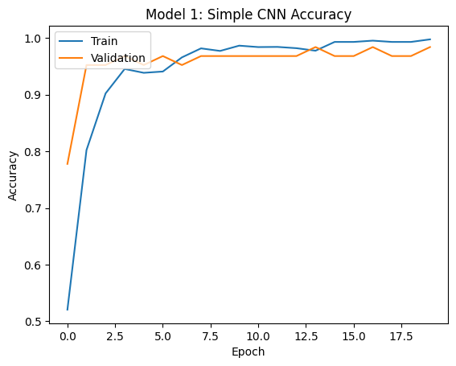

```python
plt.plot(history_cnn.history['accuracy'])
plt.plot(history_cnn.history['val_accuracy'])
plt.title('Model 1: Simple CNN Accuracy')
plt.ylabel('Accuracy')
plt.xlabel('Epoch')
plt.legend(['Train', 'Validation'], loc='upper left')
plt.show()
```

```python
model_cnn_train_perf = model_performance_classification(model_cnn, X_train_normalized, y_train)

print("Train performance metrics")
print(model_cnn_train_perf)
```

```
Train performance metrics
   Accuracy  Recall  Precision  F1 Score
0       1.0     1.0        1.0       1.0
```

```python
plot_confusion_matrix(model_cnn, X_train_normalized, y_train)
```

```python
model_cnn_valid_perf = model_performance_classification(model_cnn, X_val_normalized, y_val)

print("Validation performance metrics")
print(model_cnn_valid_perf)
```

```
Validation performance metrics
   Accuracy    Recall  Precision  F1 Score
0  0.984127  0.984127   0.984608  0.984119
```

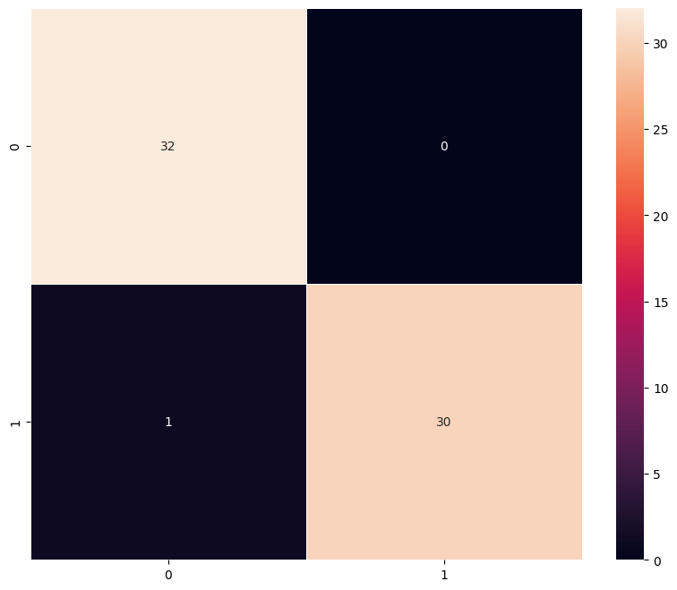

```python
plot_confusion_matrix(model_cnn, X_val_normalized, y_val)
```

#### **Vizualizing the predictions**

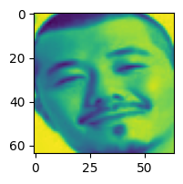

```
Predicted Label [[0.00052156]]
True Label Label    0
Name: 603, dtype: int64
```

```
Predicted Label [[0.00736702]]
True Label Label    0
Name: 512, dtype: int64
```

[output not shown]

```python
##Visualizing the predicted and correct label of images from validation data
plt.figure(figsize=(2,2))
plt.imshow(X_val[2])
plt.show()
print('Predicted Label', model_cnn.predict((X_val_normalized[2].reshape(1,64,64,1))))   # reshaping the input image as we are only trying to predict using a single image
print('True Label', y_val.iloc[2])

plt.figure(figsize=(2,2))
plt.imshow(X_val[33])
plt.show()
print('Predicted Label', model_cnn.predict((X_val_normalized[33].reshape(1,64,64,1))))  # reshaping the input image as we are only trying to predict using a single image
print('True Label', y_val.iloc[33])

plt.figure(figsize=(2,2))
plt.imshow(X_val[62])
plt.show()
print('Predicted Label', model_cnn.predict((X_val_normalized[62].reshape(1,64,64,1))))  # reshaping the input image as we are only trying to predict using a single image
print('True Label', y_val.iloc[62])
```

- Model is performing really well given it is not very complex.
- Observing 100 % accuracy on training data and ~98.5% on validation data with balanced precision and recall.

## **Model 2: (VGG-16 (Base))**

```python
vgg_model = VGG16(weights='imagenet', include_top=False, input_shape=(64,64,3))
vgg_model.summary()
```

[output not shown]

[output cut: 17 more lines]

```
 block4_pool (MaxPooling2D)  (None, 4, 4, 512)         0

 block5_conv1 (Conv2D)       (None, 4, 4, 512)         2359808

 block5_conv2 (Conv2D)       (None, 4, 4, 512)         2359808

 block5_conv3 (Conv2D)       (None, 4, 4, 512)         2359808

 block5_pool (MaxPooling2D)  (None, 2, 2, 512)         0

=================================================================
Total params: 14,714,688
Trainable params: 14,714,688
Non-trainable params: 0
_________________________________________________________________
```

```python
# Making all the layers of the VGG model non-trainable. i.e. freezing them
for layer in vgg_model.layers:
    layer.trainable = False
```

```python
model_vgg_base = Sequential()

# Adding the convolutional part of the VGG16 model from above
model_vgg_base.add(vgg_model)

# Flattening the output of the VGG16 model because it is from a convolutional layer
model_vgg_base.add(Flatten())

# Adding a dense output layer
model_vgg_base.add(Dense(1, activation='sigmoid'))

# Compile model
model_vgg_base.compile(optimizer='adam', loss='binary_crossentropy', metrics=['accuracy'])

model_vgg_base.summary()
```

[output not shown]

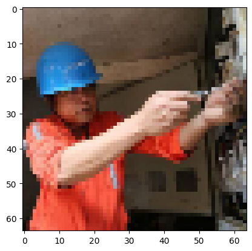

```python
plt.imshow(X_val_c_normalized[62]);
```

```python
train_datagen = ImageDataGenerator()
# Epochs
epochs = 20
# Batch size
batch_size = 16

history_vgg_base = model_vgg_base.fit(train_datagen.flow(X_train_c_normalized, y_train_c,
                                       batch_size=batch_size,
                                       seed=42,
                                       shuffle=False),
                    epochs=epochs,
                    steps_per_epoch=X_train_c_normalized.shape[0] // batch_size,
                    validation_data=(X_val_c_normalized, y_val_c),
                    verbose=1)
```

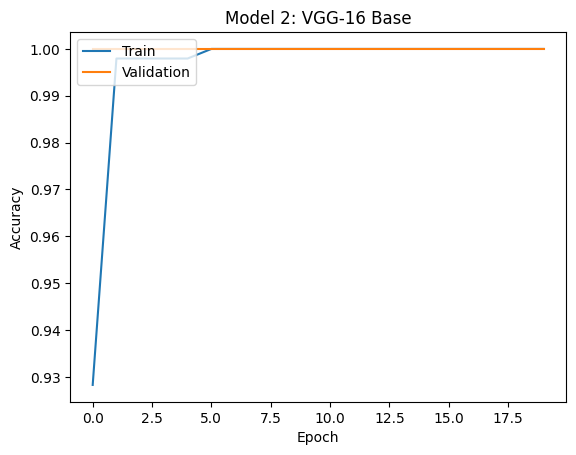

```python
plt.plot(history_vgg_base.history['accuracy'])
plt.plot(history_vgg_base.history['val_accuracy'])
plt.title('Model 2: VGG-16 Base')
plt.ylabel('Accuracy')
plt.xlabel('Epoch')
plt.legend(['Train', 'Validation'], loc='upper left')
plt.show()
```

```python
model_vgg_base_train_perf = model_performance_classification(model_vgg_base, X_train_c_normalized, y_train)

print("Train performance metrics")
print(model_vgg_base_train_perf)
```

```
Train performance metrics
   Accuracy  Recall  Precision  F1 Score
0       1.0     1.0        1.0       1.0
```

```python
plot_confusion_matrix(model_vgg_base, X_train_c_normalized, y_train)
```

```python
model_vgg_base_valid_perf = model_performance_classification(model_vgg_base, X_val_c_normalized, y_val)

print("Validation performance metrics")
print(model_vgg_base_valid_perf)
```

```
Validation performance metrics
   Accuracy  Recall  Precision  F1 Score
0       1.0     1.0        1.0       1.0
```

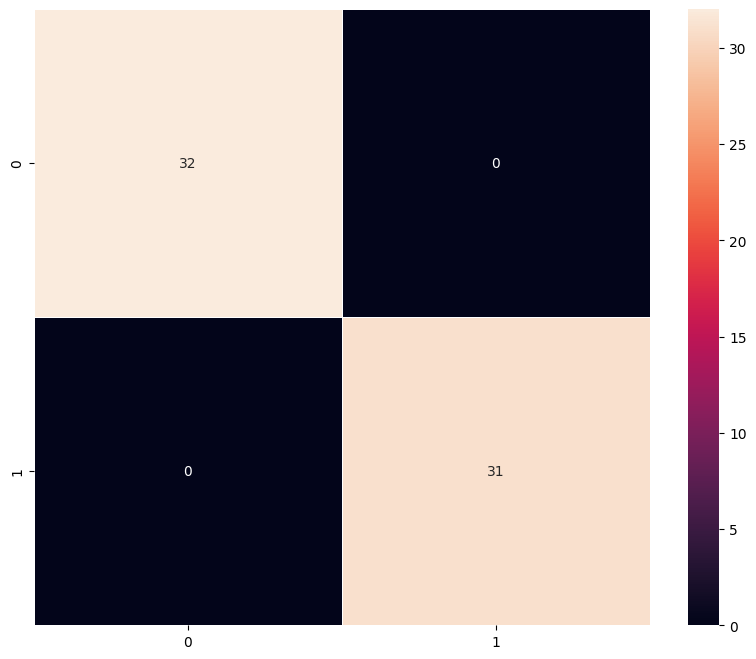

```python
plot_confusion_matrix(model_vgg_base, X_val_c_normalized, y_val)
```

#### **Visualizing the predictions**

```python
##Visualizing the predicted and correct label of images from test data
plt.figure(figsize=(2,2))
plt.imshow(X_val[13])
plt.show()
print('Predicted Label', model_vgg_base.predict((X_val_c_normalized[13].reshape(1,64,64,3))))   # reshaping the input image as we are only trying to predict using a single image
print('True Label', y_val_c.iloc[13])                                               # using inverse_transform() to get the output label from the output vector

plt.figure(figsize=(2,2))
plt.imshow(X_val[33])
plt.show()
print('Predicted Label', model_vgg_base.predict((X_val_c_normalized[33].reshape(1,64,64,3))))  # reshaping the input image as we are only trying to predict using a single image
print('True Label', y_val_c.iloc[33])                                              # using inverse_transform() to get the output label from the output vector

plt.figure(figsize=(2,2))
plt.imshow(X_val[62])
plt.show()
print('Predicted Label', model_vgg_base.predict((X_val_c_normalized[62].reshape(1,64,64,3))))  # reshaping the input image as we are only trying to predict using a single image
print('True Label', y_val_c.iloc[62])                                              # using inverse_transform() to get the output label from the output vector
```

```
Predicted Label [[0.99458545]]
True Label Label    1
Name: 559, dtype: int64
```

```
Predicted Label [[0.02748739]]
True Label Label    0
Name: 512, dtype: int64
```

[output not shown]

- Model is performing really well even without FFNN layers of VGG-16 model.
- Observing 100 % accuracy on both training data and validation data with perfect precision and recall
- Probabilites for some of the observations might become more accurate with FFNN layers increasing confidence of predictions.

## **Model 3 : (VGG-16 (Base + FFNN))**

```python
# Define the vgg base model with ffnn block
model_vgg_ffnn = Sequential()
model_vgg_ffnn.add(vgg_model)
model_vgg_ffnn.add(Flatten())
model_vgg_ffnn.add(Dense(64, activation='relu'))
model_vgg_ffnn.add(Dropout(0.4))
model_vgg_ffnn.add(Dense(32, activation='relu'))
model_vgg_ffnn.add(Dense(1, activation='sigmoid'))
```

```python
# Compile model
model_vgg_ffnn.compile(optimizer='adam', loss='binary_crossentropy', metrics=['accuracy'])
model_vgg_ffnn.summary()
```

[output not shown]

```python
epochs = 20
batch_size = 16
train_datagen = ImageDataGenerator()
history_vgg_ffnn = model_vgg_ffnn.fit(
    train_datagen.flow(X_train_c_normalized, y_train_c, batch_size=batch_size, seed=42, shuffle=False),
    epochs=epochs,
    steps_per_epoch=X_train_c_normalized.shape[0] // batch_size,
    validation_data=(X_val_c_normalized, y_val_c),
    verbose=1
)
```

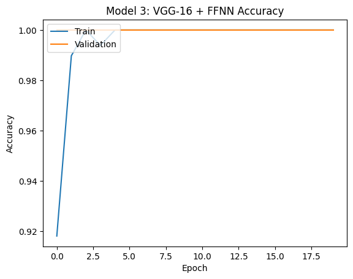

```python
# Plot train/validation accuracy
plt.plot(history_vgg_ffnn.history['accuracy'])
plt.plot(history_vgg_ffnn.history['val_accuracy'])
plt.title('Model 3: VGG-16 + FFNN Accuracy')
plt.ylabel('Accuracy')
plt.xlabel('Epoch')
plt.legend(['Train', 'Validation'], loc='upper left')
plt.show()
```

```python
# Print performance on train set

model_vgg_ffnn_train_perf = model_performance_classification(model_vgg_ffnn, X_train_c_normalized, y_train)

print("Train performance metrics")
print(model_vgg_ffnn_train_perf)
```

```
Train performance metrics
   Accuracy  Recall  Precision  F1 Score
0       1.0     1.0        1.0       1.0
```

```python
plot_confusion_matrix(model_vgg_ffnn, X_train_c_normalized, y_train)
```

```python
# Print performance on validation set
model_vgg_ffnn_valid_perf = model_performance_classification(model_vgg_ffnn, X_val_c_normalized, y_val)

print("Validation performance metrics")
print(model_vgg_ffnn_valid_perf)
```

```
Validation performance metrics
   Accuracy  Recall  Precision  F1 Score
0       1.0     1.0        1.0       1.0
```

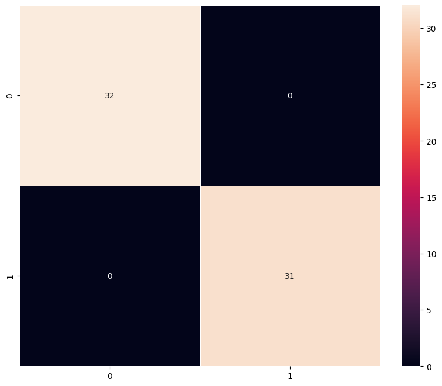

```python
plot_confusion_matrix(model_vgg_base, X_val_c_normalized, y_val)
```

#### **Visualizing the predictions**

```python
##Visualizing the predicted and correct label of images from test data
plt.figure(figsize=(2,2))
plt.imshow(X_val[13])
plt.show()
print('Predicted Label', model_vgg_ffnn.predict((X_val_c_normalized[13].reshape(1,64,64,3))))   # reshaping the input image as we are only trying to predict using a single image
print('True Label', y_val_c.iloc[13])                                               # using inverse_transform() to get the output label from the output vector

plt.figure(figsize=(2,2))
plt.imshow(X_val[33])
plt.show()
print('Predicted Label', model_vgg_ffnn.predict((X_val_c_normalized[33].reshape(1,64,64,3))))  # reshaping the input image as we are only trying to predict using a single image
print('True Label', y_val_c.iloc[33])                                              # using inverse_transform() to get the output label from the output vector

plt.figure(figsize=(2,2))
plt.imshow(X_val[62])
plt.show()
print('Predicted Label', model_vgg_ffnn.predict((X_val_c_normalized[62].reshape(1,64,64,3))))  # reshaping the input image as we are only trying to predict using a single image
print('True Label', y_val_c.iloc[62])                                              # using inverse_transform() to get the output label from the output vector
```

```
Predicted Label [[0.99998456]]
True Label Label    1
Name: 559, dtype: int64
```

```
Predicted Label [[2.261545e-05]]
True Label Label    0
Name: 512, dtype: int64
```

[output not shown]

- Model is performing perfectly with FFNN layers on top of VGG-16 model.
- Observing 100 % accuracy on both training data and validation data with perfect precision and recall
- Probabilites of the predictions have become more accurate with FFNN layers increasing confidence on predictions.